# Лабораторная работа №6: Реализация основных моделей в подходе сетей Петри

Автор

принадлежность

Федорова Анжелика Игоревна

Российский университет дружбы народов

# 1 Цель работы

Реализовать модель эпидемии SIR с использованием подхода сетей Петри, выполнить детерминированную и стохастическую симуляции, провести параметрические эксперименты и исследовать поведение системы.

# 2 Задание

В ходе работы необходимо:

1. Создать рабочий каталог для кода
2. Установить необходимые пакеты
3. Реализовать модель SIR в виде сети Петри
4. Выполнить базовый прогон (детерминированная и стохастическая симуляции)
5. Провести сканирование параметра β
6. Создать анимацию динамики
7. Сформировать итоговый отчёт со сравнительными графиками
8. Оформить отчёт

# 3 Ход работы

## 3.1 1. Подготовка проекта

Была создана структура проекта с использованием DrWatson:

- `src/` — код модели
- `scripts/` — исполняемые скрипты
- `plots/` — результаты
- `data/` — сохранённые CSV-файлы

Установлены пакеты:

```julia
using Pkg
Pkg.add([
  "AlgebraicPetri", "Catlab", "OrdinaryDiffEq",
  "Plots", "DataFrames", "CSV", "DrWatson", "Random"
])
```

## 3.2 2. Реализация модели

Модель реализована в файле `src/SIRPetri.jl`.

### 3.2.1 Описание модели SIR

Модель описывает переходы между тремя состояниями:

- **S** (Susceptible, восприимчивые) — могут заразиться;
- **I** (Infectious, инфицированные) — заражают других и выздоравливают;
- **R** (Recovered, выздоровевшие / с иммунитетом) — больше не участвуют в эпидемии.

Сеть Петри содержит два перехода:

- `infection`: S + I → I + I (скорость β)
- `recovery`: I → R (скорость γ)

### 3.2.2 Код модуля

```julia
module SIRPetri

using AlgebraicPetri
using Catlab.CategoricalAlgebra
using Catlab.Graphics
using OrdinaryDiffEq
using Plots
using DataFrames
using Random

export build_sir_network, simulate_deterministic, simulate_stochastic
export plot_sir, to_graphviz_sir

function build_sir_network(β = 0.3, γ = 0.1)
    states = [:S, :I, :R]
    net = LabelledPetriNet(
        states,
        :infection => ([:S, :I] => [:I, :I]),
        :recovery  => ([:I] => [:R]),
    )
    u0 = [990.0, 10.0, 0.0]
    return net, u0, states
end

function sir_ode(net, rates = [0.3, 0.1])
    function f!(du, u, p, t)
        S, I, R = u
        β, γ = rates
        infection_rate = β * S * I
        recovery_rate  = γ * I
        du[1] = -infection_rate
        du[2] =  infection_rate - recovery_rate
        du[3] =  recovery_rate
    end
    return f!
end

function simulate_deterministic(net, u0, tspan; saveat = 0.1, rates = [0.3, 0.1])
    f    = sir_ode(net, rates)
    prob = ODEProblem(f, u0, tspan)
    sol  = solve(prob, Tsit5(), saveat = saveat)
    df   = DataFrame(time = sol.t, S = sol[1,:], I = sol[2,:], R = sol[3,:])
    return df
end

function simulate_stochastic(net, u0, tspan; rates = [0.3, 0.1], rng = Random.GLOBAL_RNG)
    u = copy(u0); t = 0.0
    times = [t]; states = [copy(u)]
    β, γ = rates
    while t < tspan[2]
        S, I, R = u
        a_inf = β * S * I
        a_rec = γ * I
        a0 = a_inf + a_rec
        a0 == 0 && break
        dt = -log(rand(rng)) / a0
        if rand(rng) * a0 < a_inf
            u[1] -= 1; u[2] += 1
        else
            u[2] -= 1; u[3] += 1
        end
        t += dt
        if t <= tspan[2]
            push!(times, t); push!(states, copy(u))
        end
    end
    df = DataFrame(time = times,
                   S = [s[1] for s in states],
                   I = [s[2] for s in states],
                   R = [s[3] for s in states])
    return df
end

function plot_sir(df)
    plot(df.time, [df.S, df.I, df.R],
         label = ["S (Susceptible)" "I (Infected)" "R (Recovered)"],
         xlabel = "Time", ylabel = "Population", linewidth = 2)
end

function to_graphviz_sir(net)
    return to_graphviz(net, prog = "dot")
end

end # module
```

Скриншот файла в редакторе:

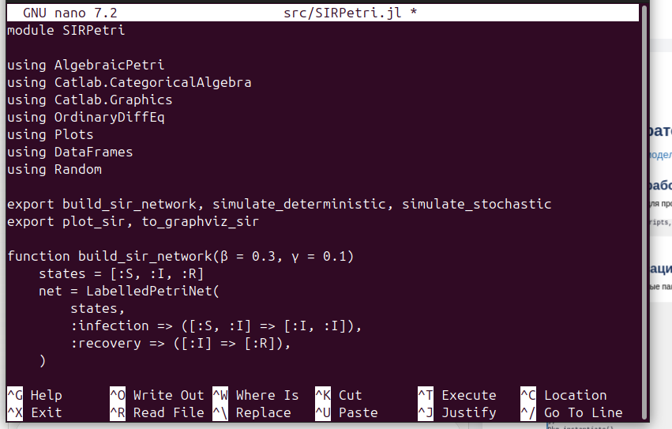

Файл src/SIRPetri.jl в редакторе nano